# Fitting consumer resource - state-space model

Author

Benjamin Rosenbaum

## Model

The Rosenzweig-MacArthur predator-prey model with logistic growth and Type II functional response reads

$$\begin{aligned}
\frac{dN_1}{dt} &= r(1-\frac{N_1}{K})N_1 -\frac{ahN_1}{1+ahN_1}N_2 \\
\frac{dN_2}{dt} &= e\frac{ahN_1}{1+ahN_1}N_2 -d N_2
\end{aligned}$$

Using a state-space model (including observation and process errors), we will fit all datapoints $(N_{1,t},N_{2,t})$ of $m$ time series replicates with a joint set of parameters $r,K,a,h,e,d$ (“complete pooling”). For each observation $N_{1,i,j},N_{2,i,j}$ in $t_i$ of time series $j$, underlying true states `Ntrue1[j,i]`, `Ntrue2[j,i]` are free parameters, which are estimated too.

Additionally, we fit time series for $m_c$ control (single-species) time series of prey ($N_2=0$, logistic growth)
$$\frac{dN_1}{dt} = r(1-\frac{N_1}{K})N_1$$
and $m_c$ control time series of predator ($N_1=0$, exponential decline)
$$\frac{dN_2}{dt} = -dN_2$$
These control data will provide additional information on $r,K$ and $d$. Underlying true states `N1Ctrue[j,i]` for the prey and `N2Ctrue[j,i]` for the predator time series, respectively, are free parameters too.

## Data preparation

The dataset `data_example_consumer_resource.csv` contains `m=6` timeseries with `n=18` observations of densities [ind] each, including their dates [h]. The fraction of the observed volume for sampling was `f=0.1`. Data preparation is identical to the OBS model manual.

```r
rm(list=ls())
library("rstan")
```

```r
data.in = read.csv("data_example_consumer_resource.csv", row.names=1)

head(data.in)
```

```
      X1  X2  X3  X4  X5   X6   X7   X8   X9 X10 X11 X12  X13  X14  X15  X16
time   0  12  24  36  48   60   72   96  120 144 168 192  216  240  264  288
N1   200 207 228 370 664  958 1330 1253 1017 827 546 276  240  409 1094 1452
N2   189 205 283 461 716 1002 1212 1032  610 227 245 600 1128 1383 1330  862
N3   201 222 280 394 595  822 1097 1097  779 422 303 431 1001 1439 1161  912
N4   198 214 241 428 641  924 1281 1413 1261 736 288 214  361  761 1168 1036
N5   191 204 274 483 772 1060 1251 1100  688 333 267 612 1320 1595 1542 1128
      X17 X18
time  312 336
N1   1291 903
N2    329 119
N3    400 146
N4    596 285
N5    817 389
```

```r
n = 18
m = 6
mc = 3

times = as.numeric(data.in[1, ])
N1 = unname(as.matrix(data.in[2:(m+1), ]))
N2 = unname(as.matrix(data.in[(m+2):(2*m+1), ]))
N1C = unname(as.matrix(data.in[(2*m+2):(2*m+1+mc), ]))
N2C = unname(as.matrix(data.in[(2*m+2+mc):((2*m+1+2*mc)), ]))

data = list(n = n,
            m = m,
            mc = mc,
            t = times,
            N1 = N1,
            N2 = N2,
            N1C  = N1C,
            N2C  = N2C,
            f = 0.1)

str(data)
```

```
List of 9
 $ n  : num 18
 $ m  : num 6
 $ mc : num 3
 $ t  : num [1:18] 0 12 24 36 48 60 72 96 120 144 ...
 $ N1 : int [1:6, 1:18] 200 189 201 198 191 174 207 205 222 214 ...
 $ N2 : int [1:6, 1:18] 48 38 41 42 56 40 35 29 27 34 ...
 $ N1C: int [1:3, 1:18] 40 51 51 96 144 117 259 370 411 637 ...
 $ N2C: int [1:3, 1:18] 195 185 201 104 98 105 58 56 44 40 ...
 $ f  : num 0.1
```

## Stan model

The Stan model is coded as a string, which is compiled later. A step by step walkthrough is given below.

```r
stanmodelcode="
functions{
  vector odemodel(real t, vector N, vector p){
    // p[1]=r, p[2]=K, p[3]=b, p[4]=h, p[5]=e, p[6]=d
    vector[2] dNdt;
    dNdt[1] = p[1]*N[1]*(1.0-N[1]/p[2])-p[3]*N[1]*N[2]/(1.0+p[3]*p[4]*N[1]);
    dNdt[2] = p[5]*p[3]*N[1]*N[2]/(1.0+p[3]*p[4]*N[1])-p[6]*N[2];
    return dNdt;
  }
}

data{
  int n; // observations
  int m; // replicates
  int mc; // replicates control
  real t[n];
  array[m,n] int N1;
  array[m,n] int N2;
  array[mc,n] int N1C;
  array[mc,n] int N2C;
  real f;
}

parameters{
  real<lower=0> r;
  real<lower=0> K;
  real<lower=0> b;
  real<lower=0> h;
  real<lower=0, upper=1> e;
  real<lower=0> d;
  vector<lower=0>[2] sigma;
  vector<lower=0>[2] tau;
  matrix<lower=0>[m,n] N1true; // states in times t
  matrix<lower=0>[m,n] N2true; // states in times t
  matrix<lower=0>[mc,n] N1Ctrue; // states in times t
  matrix<lower=0>[mc,10] N2Ctrue; // states in times t, only 10 datapoints
}

model{
  vector[6] p;
  array[1] vector[2] Nsim; // simulated values, matrix. dim1 = 1 point in time, dim2 = dim_ODE = 2
  array[1] vector[1] NCsim; // simulated values, matrix. dim1 = 1 point in time, dim2 = dim_ODE = 1

  // priors
  r ~ lognormal(-2,1);
  K ~ lognormal(9,1);
  b ~ gamma(2,1);
  h ~ gamma(2,1);
  // e ~ beta(2,2);
  d ~ gamma(2,1);
  // sigma ~ gamma(2,1);
  sigma ~ lognormal(-2,1);
  tau ~ gamma(2,0.1);

  for(i in 1:m){
    N1true[i,1] ~ normal(0,2000);
    N2true[i,1] ~ normal(0,2000);
  }
  for(i in 1:mc){
    N1Ctrue[i,1] ~ normal(0,2000);
    N2Ctrue[i,1] ~ normal(0,2000);
  }

  //---------------------------------------------------------------------------
  // 2-species data
  //---------------------------------------------------------------------------

  // parameters for integrator
  p[1] = r;
  p[2] = K;
  p[3] = b;
  p[4] = h;
  p[5] = e;
  p[6] = d;

  // process equation
  for(j in 1:m){
    for(i in 1:(n-1)){
      Nsim = ode_rk45(odemodel, [N1true[j,i],N2true[j,i]]', t[i], {t[i+1]}, p);
      N1true[j,i+1] ~ lognormal(log(Nsim[1,1]), sigma[1]);
      N2true[j,i+1] ~ lognormal(log(Nsim[1,2]), sigma[2]);
    }
  }
  // observation equation
  for(j in 1:m){
    for(i in 1:n){
      N1[j,i] ~ neg_binomial_2(N1true[j,i]*f, tau[1]);
      N2[j,i] ~ neg_binomial_2(N2true[j,i]*f, tau[2]);
    }
  }

  //---------------------------------------------------------------------------
  // resource: control data
  //---------------------------------------------------------------------------

  // process equation
  for(j in 1:mc){
    for(i in 1:(n-1)){
      NCsim[1,1] = K/( 1.0+(K-N1Ctrue[j,i])/N1Ctrue[j,i] * exp(-r*(t[i+1]-t[i]))); // analytical solution
      N1Ctrue[j,i+1] ~ lognormal(log(NCsim[1,1]), sigma[1]);
    }
  }
  // observation equation
  for(j in 1:mc){
    // observation error
    for(i in 1:n){
      N1C[j,i] ~ neg_binomial_2(N1Ctrue[j,i]*f, tau[1]);
    }
  }

  //---------------------------------------------------------------------------
  // consumer: control data
  //---------------------------------------------------------------------------

  // process equation
  for(j in 1:mc){
    for(i in 1:(10-1)){ // only 10 datapoints
      NCsim[1,1] = N2Ctrue[j,i] * exp(-d*(t[i+1]-t[i])); // analytical solution
      N2Ctrue[j,i+1] ~ lognormal(log(NCsim[1,1]), sigma[2]);
    }
  }
  // observation equation
  for(j in 1:mc){
    for(i in 1:10){ // only 10 datapoints
      N2C[j,i] ~ neg_binomial_2(N2Ctrue[j,i]*f, tau[2]);
    }
  }

}
"
```

### functions{ } block

This is identical to the OBS model manual.

```
  vector odemodel(real t, vector N, vector p){
    // p[1]=r, p[2]=K, p[3]=b, p[4]=h, p[5]=e, p[6]=d
    vector[2] dNdt;
    dNdt[1] = p[1]*N[1]*(1.0-N[1]/p[2])-p[3]*N[1]*N[2]/(1.0+p[3]*p[4]*N[1]);
    dNdt[2] = p[5]*p[3]*N[1]*N[2]/(1.0+p[3]*p[4]*N[1])-p[6]*N[2];
    return dNdt;
  }
```

### data{ } block

This is identical to the OBS model manual.

```
  int n; // observations
  int m; // replicates
  int mc; // replicates control
  real t[n];
  array[m,n] int N1;
  array[m,n] int N2;
  array[mc,n] int N1C;
  array[mc,n] int N2C;
  real f;
```

### parameters{ } block

Here, all free parameters are declared. This includes model parameters `r`,`K`,`b`,`h`,`e`,`d`, 2 parameters `sigma` for the process residual distribution (scale parameter of lognormal) and `tau` for the observation residual distribution (overdispersion of the negative binomial). Additionally, for all `m` x `n` observations, the underlying true states `Ntrue1` (prey) and `Ntrue2` (predator) are estimated. Same for control timeseries `N2Ctrue`, `N2Ctrue`. All parameters are required to be positive.

For the control data of the predator, we choose to use only the first 10 observations. The observed populations are extinct at that point. Predicting true states `N2Ctrue[i,j]` after that (`i>10`) would drive these estimates arbitrarily close to zero and potentially lead to numerical issues.

```
  real<lower=0> r;
  real<lower=0> K;
  real<lower=0> b;
  real<lower=0> h;
  real<lower=0, upper=1> e;
  real<lower=0> d;
  vector<lower=0>[2] sigma;
  vector<lower=0>[2] tau;
  matrix<lower=0>[m,n] N1true; // states in times t
  matrix<lower=0>[m,n] N2true; // states in times t
  matrix<lower=0>[mc,n] N1Ctrue; // states in times t
  matrix<lower=0>[mc,10] N2Ctrue; // states in times t, only 10 datapoints
```

### model{ } block

This block defines how the posterior computed, using prior distributions and the likelihood function. First, some intermediate variables for the ODE simulation are declared. `p` is a vector which stores all 6 model parameters. `Nsim` will contain the output of the numerical integration with dimensions `1` (predict only next state), and the second dimension is number of states (2). `NCsim` will contain predictions for single species control time series, so only 1 state. This array-vector combination is required with the ODE solver function.

```
  vector[6] p;
  array[1] vector[2] Nsim; // simulated values, matrix. dim1 = 1 point in time, dim2 = dim_ODE = 2
  array[1] vector[1] NCsim; // simulated values, matrix. dim1 = 1 point in time, dim2 = dim_ODE = 1
```

Priors: This is identical to the OBS and PROC model manual, initial densities parameters `N...true[i,1]` are assigned a weak prior, too.

[output not shown]

After the priors are defined, predictions are computed. We start with the 2-species mixtures, and then single species time series for prey and predator (control data).

For the 2-species time series, predictions are computed via numerically integrating the ODE, which requires all model parameters are stored in one vector `p`.

```
  //---------------------------------------------------------------------------
  // 2-species data
  //---------------------------------------------------------------------------

  // parameters for integrator
  p[1] = r;
  p[2] = K;
  p[3] = b;
  p[4] = h;
  p[5] = e;
  p[6] = d;
```

The likelihood consists of two parts: the process equations and the observation equations.

In a first loop over all `m` time series replicates and `n-1` timepoints, numerical integration is performed, to predict the next true state (`N1true[j,i+1]`,`N2true[j,i+1]`) from the current true state (`N1true[j,i]`,`N2true[j,i]`). The integration routine `ode_rk45()` is must be called in a specific format. Arguments are the function `odemodel` as defined in the `functions{}` block. The initial state is converted to an vector using `[ ]'`. Integration is performed from `t[i]` to `t[i+1]`. `p` contains the model parameters.

After computing the predicted state `Nsim` (in `t[i+1]`), it is confronted with estimate of (`N1true[j,i+1]`,`N2true[j,i+1]`): we assume a lognormal distribution, `sigma` denoting the process errors.

```
  // process equation
  for(j in 1:m){
    for(i in 1:(n-1)){
      Nsim = ode_rk45(odemodel, [N1true[j,i],N2true[j,i]]', t[i], {t[i+1]}, p);
      N1true[j,i+1] ~ lognormal(log(Nsim[1,1]), sigma[1]);
      N2true[j,i+1] ~ lognormal(log(Nsim[1,2]), sigma[2]);
    }
  }
```

Second, the true states estimates (`N1true[j,i]`, `N2true[j,i]`) are confronted with the data (`N1[j,i]`,`N2[j,i]`): a negative binomial distribution defines likelihood values. Since the data was sampled in a fraction `f=0.1`, the distribution’s mean is `N..true[,]*f`, with some overdispersion `tau`.

```
  // observation equation
  for(j in 1:m){
    for(i in 1:n){
      N1[j,i] ~ neg_binomial_2(N1true[j,i]*f, tau[1]);
      N2[j,i] ~ neg_binomial_2(N2true[j,i]*f, tau[2]);
    }
  }
```

Next, we compute one-step-ahead predictions for the single species prey time series (control data). They follow logistic growth, so we can compute them analytically, i.e. with a direct formula instead of numerical integration:

$$\widehat{N}_1(t_{i+1})=\frac{K}{ 1+\frac{K-N_{1,i}}{N_{1,i}}e^{-r(t_{i+1}-t_{i})} }$$
This is generally faster than performing numerical integration. If no analytical formulation is available, numerical integration has to be performed by either using the same ODE function as above with initial values `[N1C[j,i], 0]'`, or by coding a separate function for the single-species growth model.

Again, we have to code both the process equations and observation equation.

```
  //---------------------------------------------------------------------------
  // resource: control data
  //---------------------------------------------------------------------------

  // process equation
  for(j in 1:mc){
    for(i in 1:(n-1)){
      NCsim[1,1] = K/( 1.0+(K-N1Ctrue[j,i])/N1Ctrue[j,i] * exp(-r*(t[i+1]-t[i]))); // analytical solution
      N1Ctrue[j,i+1] ~ lognormal(log(NCsim[1,1]), sigma[1]);
    }
  }
  // observation equation
  for(j in 1:mc){
    // observation error
    for(i in 1:n){
      N1C[j,i] ~ neg_binomial_2(N1Ctrue[j,i]*f, tau[1]);
    }
  }
```

Finally, we do the same for the single species predator time series (control data). They follow exponential decline with an analytical solution

$$\widehat{N}_2(t_{i+1})=N_{2,i}e^{-d(t_{i+1}-t_{i})}$$

Again, if no analytical formulation is available, numerical integration has to be performed by either using the same ODE function as above with initial values `[0, N2C[j,i]]'`, or by coding a separate function for the single-species predator model.

As described above, only the first 10 observations are considered (observed populations extinct after that).

Again, we have to code both the process equations and observation equation.

```
  //---------------------------------------------------------------------------
  // consumer: control data
  //---------------------------------------------------------------------------

  // process equation
  for(j in 1:mc){
    for(i in 1:(10-1)){ // only 10 datapoints
      NCsim[1,1] = N2Ctrue[j,i] * exp(-d*(t[i+1]-t[i])); // analytical solution
      N2Ctrue[j,i+1] ~ lognormal(log(NCsim[1,1]), sigma[2]);
    }
  }
  // observation equation
  for(j in 1:mc){
    for(i in 1:10){ // only 10 datapoints
      N2C[j,i] ~ neg_binomial_2(N2Ctrue[j,i]*f, tau[2]);
    }
  }
```

## Model fitting

This is identical to the OBS model manual.

```r
# stan options
chains = 3
rstan_options(auto_write = TRUE)
options(mc.cores = chains)
iter   =  4000
warmup =  2000
```

Then starting values for all free parameters are provided as a list (in case of multiple chains: a list of lists). For the time series true states estimates `Ntrue`, observed data scaled up from the sampled fraction `f` to the total volume are a natural choice (we add 1 in case of zeros in the data to ensure positivity). Remaining parameters are given guesses. Stan usually converges quickly towards the parameter region featuring a high probability density. But with ODEs involved, good initial guesses that do not cause numerical issues in ODE integration are often required.

```r
# initial values for sampling
init=rep(list(list(r=0.1,
                   K=2e4,
                   b=0.0003,
                   h=0.5,
                   e=0.1,
                   d=0.1,
                   sigma=c(0.1,0.1),
                   tau=c(10,10),
                   N1true=data$N1+1,
                   N2true=data$N2+1,
                   N1Ctrue=data$N1C+1,
                   N2Ctrue=data$N2C[, 1:10]+1
))
,chains)
```

Finally, the model is compiled and sampling is started. For this model and this dataset, some Stan control parameters are adapted to avoid divergent transitions while sampling. See https://mc-stan.org/misc/warnings.html for more information.

```r
stanmodel = stan_model(model_code=stanmodelcode)

fit = sampling(stanmodel,
               data=data,
               iter=iter,
               warmup=warmup,
               chains=chains,
               init=init,
               control=list(adapt_delta=0.95, max_treedepth=12)
)
```

## Model diagnostics

Convergence of the MCMC chains is checked, e.g. by looking at estimated model parameters. We check the effective sample size `n_eff` and the Gelman-Rubin diagnostics `Rhat` (should be <1.01), indicating that chains have mixed.

```r
print(fit, digits=3, pars=c("r","K","b","h","e","d","sigma","tau"), probs=c(0.025, 0.5, 0.975))
```

```
Inference for Stan model: anon_model.
3 chains, each with iter=4000; warmup=2000; thin=1;
post-warmup draws per chain=2000, total post-warmup draws=6000.

              mean se_mean      sd      2.5%       50%     97.5% n_eff  Rhat
r            0.098   0.000   0.002     0.094     0.098     0.102  1543 1.000
K        20086.899   6.944 206.353 19687.143 20088.089 20503.226   883 1.004
b            0.000   0.000   0.000     0.000     0.000     0.000  1452 1.001
h            0.509   0.001   0.026     0.460     0.508     0.560  1408 1.001
e            0.048   0.000   0.003     0.042     0.048     0.054  1319 1.001
d            0.047   0.000   0.002     0.043     0.047     0.052  1819 1.001
sigma[1]     0.014   0.001   0.005     0.006     0.013     0.025   103 1.012
sigma[2]     0.114   0.000   0.013     0.092     0.114     0.140  1995 1.001
tau[1]     259.624   0.598  41.789   185.126   256.855   348.587  4889 1.000
tau[2]      81.603   0.234  21.207    48.069    79.049   128.602  8247 1.000

Samples were drawn using NUTS(diag_e) at Mon Jan 29 01:18:02 2024.
For each parameter, n_eff is a crude measure of effective sample size,
and Rhat is the potential scale reduction factor on split chains (at
convergence, Rhat=1).
```

Additionally, chains are inspected visually via trace- and density plots.

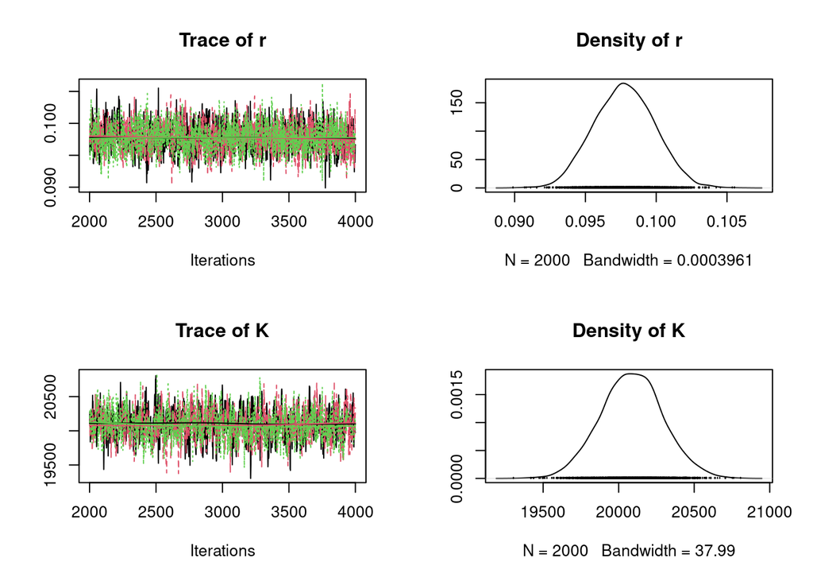

```r
library("coda")
samples=As.mcmc.list(fit)
plot(samples[, c("r","K","b","h","e","d")])
```

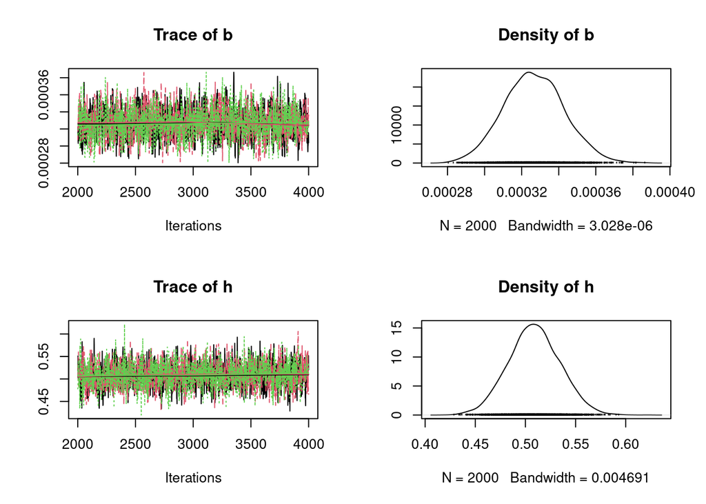

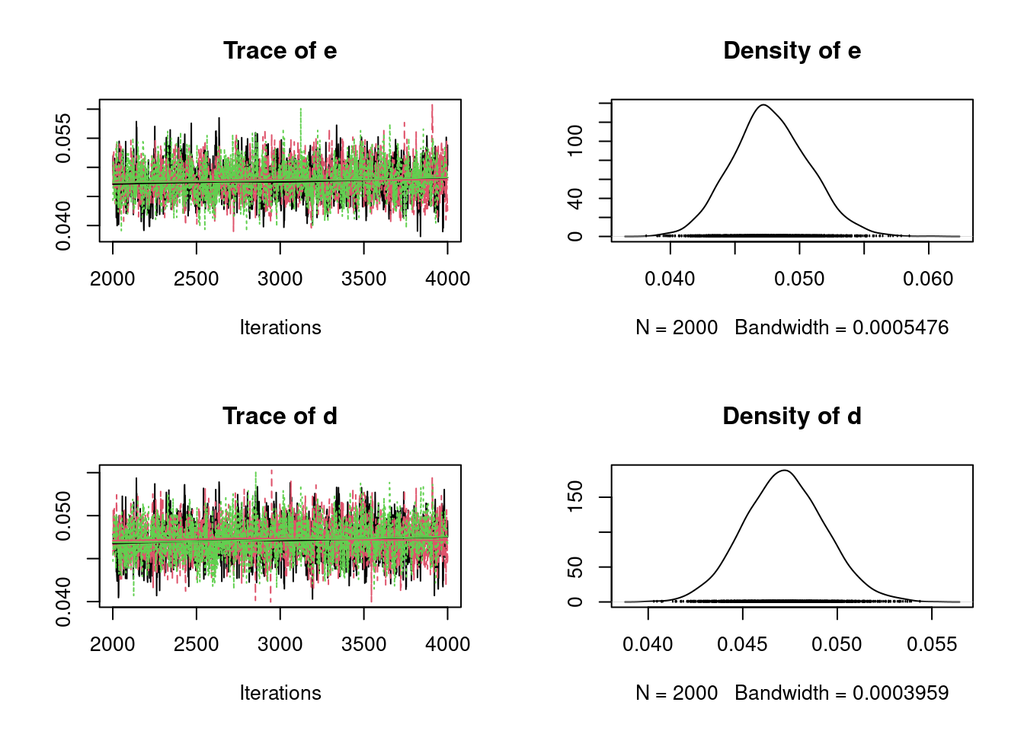

A pairs plot can detect correlations in model parameters. Almost perfect correlation would indicate non-identifiability.

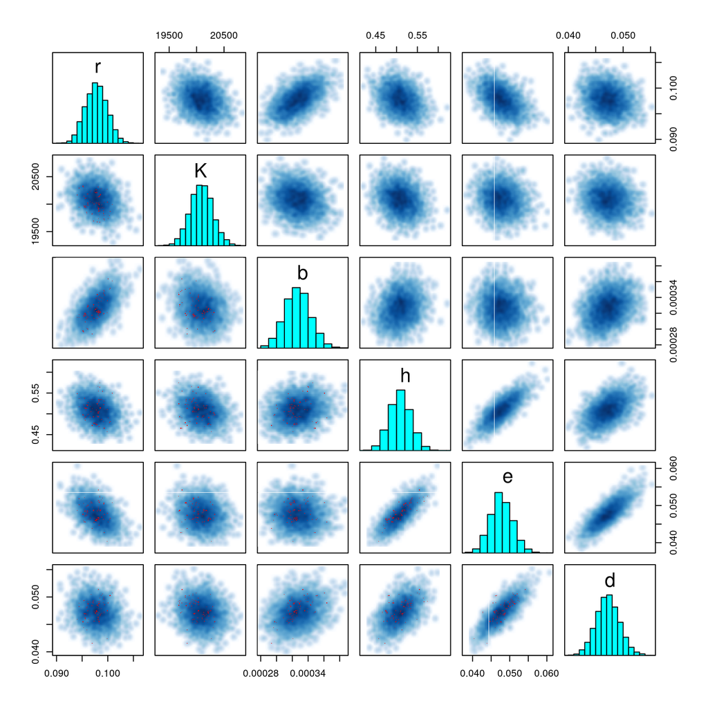

```r
pairs(fit, pars=c("r","K","b","h","e","d"))
```

## Posterior predictions

Since underlying true states (`N1true[i,j]`,`N2true[i,j]`) for all observations (`N1[i,j]`,`N2[i,j]`) are already estimated, we can directly pull their means, medians or CIs from the summary table. We plot them against the data, for simplicity as piecewise linear interpolations between observations.

Here, we only show the 2-species mixtures and omit the control time series.

```r
summary = summary(fit)$summary

head(summary)
```

```
          mean      se_mean           sd         2.5%          25%          50%
r 9.775772e-02 5.418697e-05 2.128819e-03 9.375365e-02 9.628568e-02 9.774000e-02
K 2.008690e+04 6.944364e+00 2.063535e+02 1.968714e+04 1.994834e+04 2.008809e+04
b 3.267522e-04 4.269616e-07 1.627184e-05 2.956531e-04 3.154902e-04 3.263836e-04
h 5.088732e-01 6.833614e-04 2.564207e-02 4.596127e-01 4.919730e-01 5.084740e-01
e 4.776713e-02 8.192677e-05 2.975756e-03 4.209729e-02 4.579634e-02 4.763967e-02
d 4.722170e-02 5.020982e-05 2.141476e-03 4.305841e-02 4.576981e-02 4.719707e-02
           75%        97.5%     n_eff      Rhat
r 9.922575e-02 1.019165e-01 1543.4332 0.9999021
K 2.022191e+04 2.050323e+04  882.9959 1.0040928
b 3.376046e-04 3.592081e-04 1452.4306 1.0011510
h 5.257564e-01 5.595356e-01 1408.0087 1.0014507
e 4.973963e-02 5.381936e-02 1319.2979 1.0010877
d 4.862081e-02 5.152168e-02 1819.0688 1.0014648
```

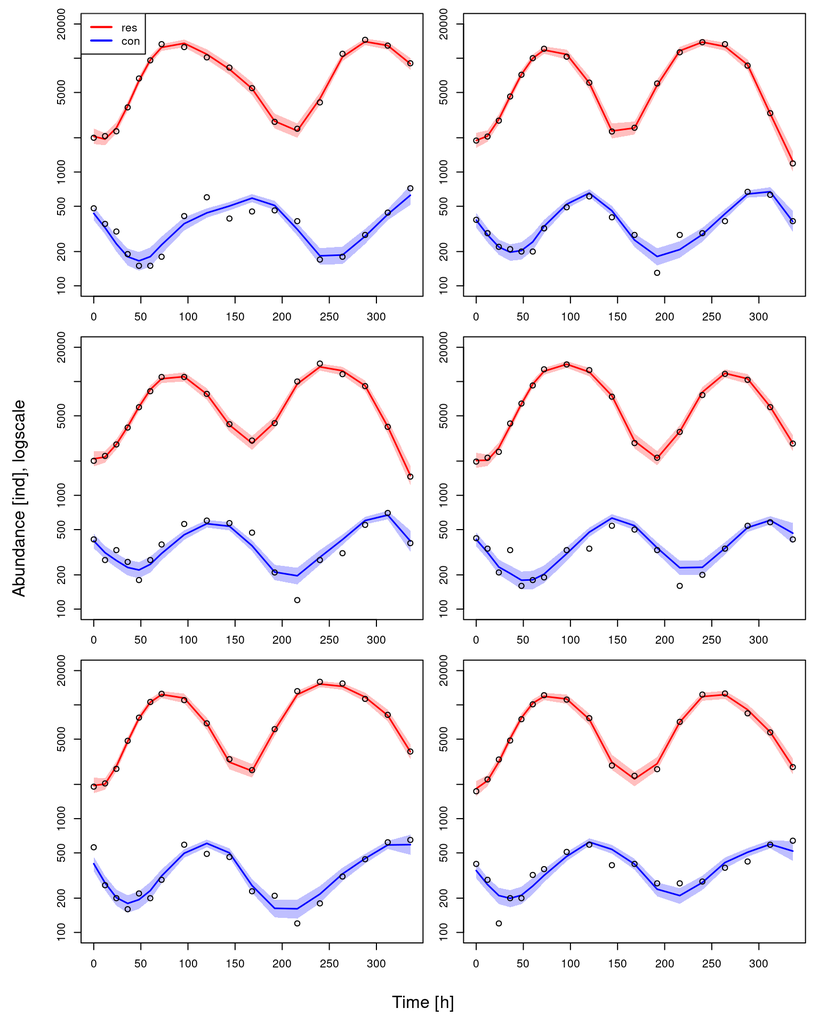

```r
N1.pred.qs = matrix(NA, nrow=3, ncol=length(data$t))
N2.pred.qs = matrix(NA, nrow=3, ncol=length(data$t))

par(mfrow=c(3,2), mar=c(3,3,0,0), oma=c(3,3,1,1))

for(i in 1:m){
  for(j in 1:length(times)){
    N1.pred.qs[, j] = summary[paste0("N1true[",i,",",j,"]"), c("2.5%", "50%", "97.5%") ]
    N2.pred.qs[, j] = summary[paste0("N2true[",i,",",j,"]"), c("2.5%", "50%", "97.5%") ]
  }

  plot(data$t, data$N1[i, ]/data$f,
       ylim=c(1e2,2e4), type="n", xlab="", ylab="", log="y")

  polygon(c(data$t, rev(data$t)), c(N1.pred.qs[1, ], rev(N1.pred.qs[3, ])),
          col = adjustcolor("red",alpha.f=0.25),  border = NA)
  lines(data$t, N1.pred.qs[2, ], col="red", lwd=1.5)
  points(data$t, data$N1[i, ]/data$f)

  polygon(c(data$t, rev(data$t)), c(N2.pred.qs[1, ], rev(N2.pred.qs[3, ])),
          col = adjustcolor("blue",alpha.f=0.25),  border = NA)
  lines(data$t, N2.pred.qs[2, ], col="blue", lwd=1.5)
  points(data$t, data$N2[i, ]/data$f)

  if(i==1) legend("topleft", c("res","con"), lwd=c(2,2), col=c("red","blue"))

}
mtext("Time [h]", side=1, outer=TRUE, line=1)
mtext("Abundance [ind], logscale", side=2, outer=TRUE, line=1)
```